# Clase 5

## Combinación con gramática tidy

Al estar incluida en el mundo `tidyverse`, podemos combinar ggplot con otros objetos a través de `%>%`. Esto es útil sobre todo en combinación con la función `group_by()` para realizar conteos de frecuencias, sumas de columnas, y otras operaciones. Probemos agrupando la cantidad de víctimas por año y haciendo un gráfico que pone `anio` en el eje `x`, el `total` en el eje `y` y usa la geometría `geom_line()`.

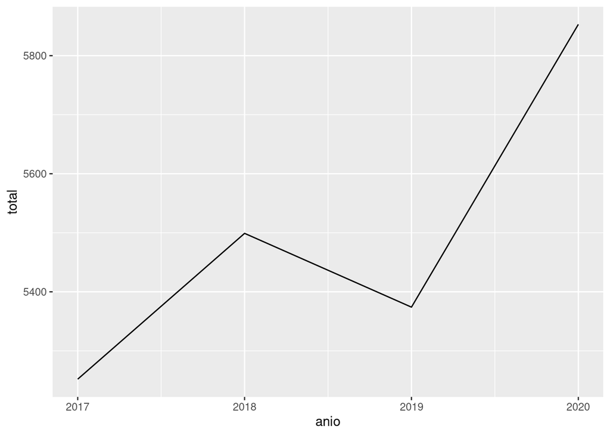

```r
> df %>% group_by(anio)%>%
+         summarise(total=sum(cant_vic))%>%
+         ggplot(aes(x=anio, y=total))+
+         geom_line()
```

Combinando con tidyverse también podemos hacer gráficos de frecuencias relativas. Vamos a usar `group_by` para obtener los porcentajes y le vamos a pasar la variable `anio` al eje x, `perc` al eje y y la geometría `geom_col()`, que crea un gráfico de barras al cual se le puede pasar un valor al argumento y.

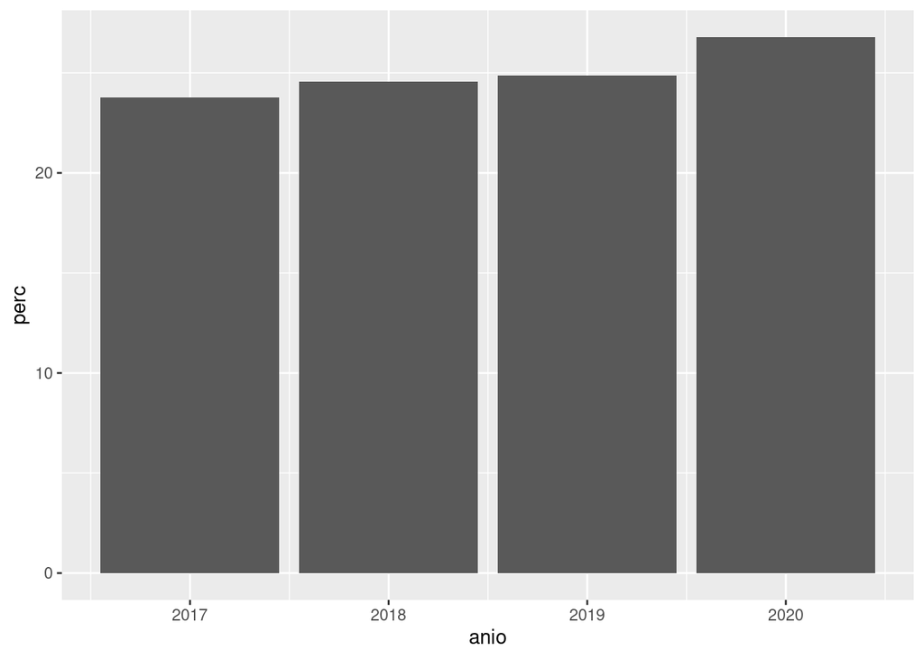

```r
> df %>% group_by(anio)%>%
+         summarise(n=n())%>%
+         ungroup()%>%
+         mutate(total=sum(n),
+                perc = (n/total)*100)%>%
+         ggplot(aes(x=anio, y=perc))+
+         geom_col()
```

## Agregándole color

Podemos mostrar más variables agregando colores a los gráficos. Vamos a hacer un conteo de las clases de arma según año, y graficarlo asignándole la variable `anio` al atributo `x`, `n` al atributo `y`, `clase_arma` al atributo `color` y le vamos a pasar la geometría `geom_line()`.

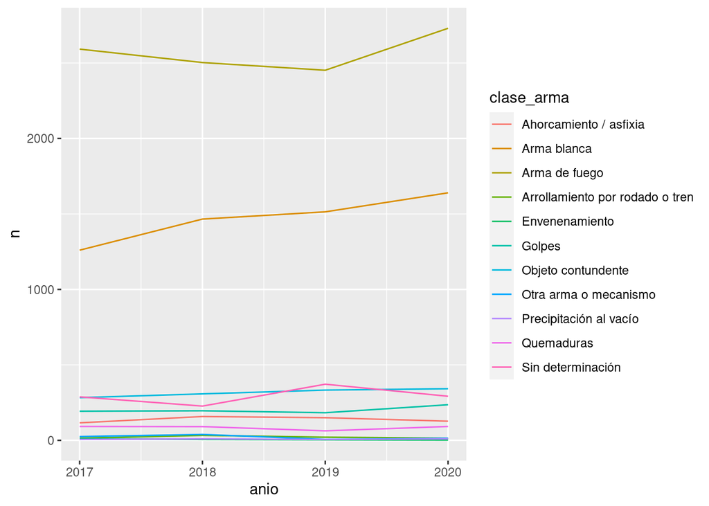

```r
> df %>% group_by(anio, clase_arma)%>%
+         summarise(n=n())%>%
+         ggplot(aes(x=anio, y=n, color=clase_arma))+
+         geom_line()
```

Vamos a hacer el gráfico de frecuencia de casos anuales pero introduciendo también la variable provincia. Repitamos el primer gráfico que hicimos pero asignándole al atributo `fill` la variable provincia, y el valor `fill` al atributo `position` dentro de la geometría.

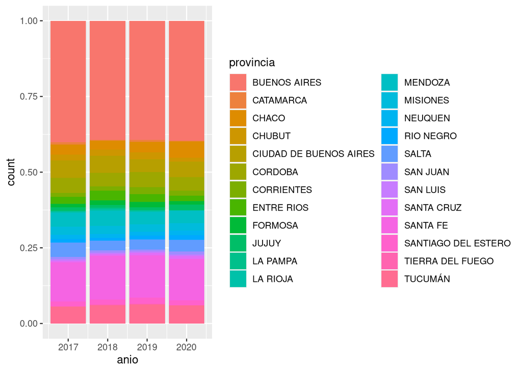

```r
> ggplot(df, aes(x=anio, fill = provincia))+
+         geom_bar(position = "fill")
```

`position = "fill"` indica que queremos que las categorías de la variable llenen la barra en una proporción de 0 a 1. Los otros dos valores que puede adoptar este argumento son `"stack"` o `"dodge"`. Prueben hacer el mismo gráfico cambiando esos valores a ver qué sucede.

`ggplot` automáticamente asigna una paleta de colores predeterminada. Sin embargo, también podemos asignar los colores que queramos manualmente. R base viene con [varios colores que podemos definir por su nombre en inglés](http://www.stat.columbia.edu/~tzheng/files/Rcolor.pdf), pero si queremos colores que no están disponibles en esta paleta podemos usar hex codes. Vamos a probarlo haciendo un gráfico de barras de la variable `sexo_inculpado`, filtrando únicamente según sexo femenino o masculino.

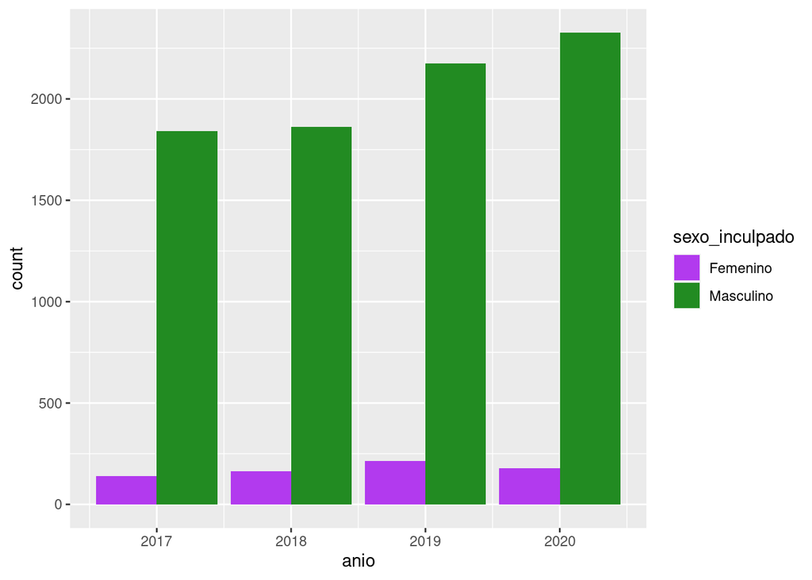

```r
> colores <- c('darkorchid2', 'forestgreen')
> df %>% filter(sexo_inculpado %in% c("Femenino", "Masculino"))%>%
+         ggplot(aes(x=anio, fill = sexo_inculpado))+
+                 geom_bar(position = "dodge")+
+         scale_fill_manual(values = colores)
```

## Otros atributos estéticos

`coord_flip()` y `theme(axis.text.x = element_text(angle = 90))` son atributos útiles para utilizar cuando las categorías del eje x son muy largas y se superponen. Por ejemplo, hagamos un gráfico de barras de la cantidad de casos totales por provincia.

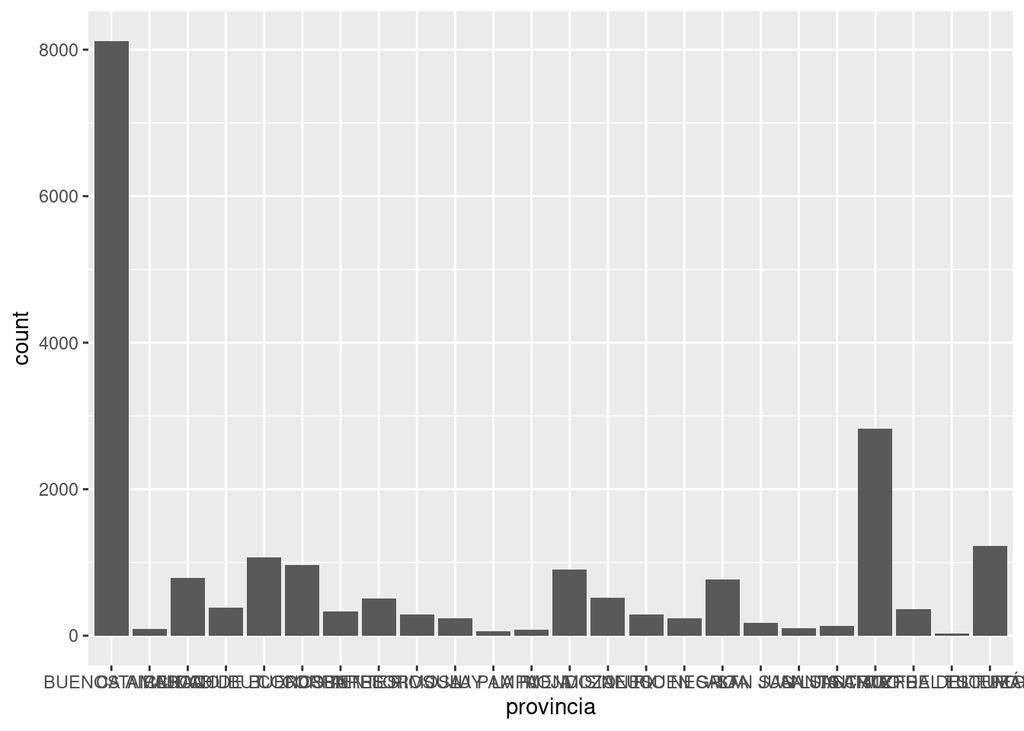

```r
> ggplot(df, aes(x=provincia))+
+         geom_bar()
```

No se ve nada bien. Ahora, probemos el mismo gráfico con `coord_flip()`.

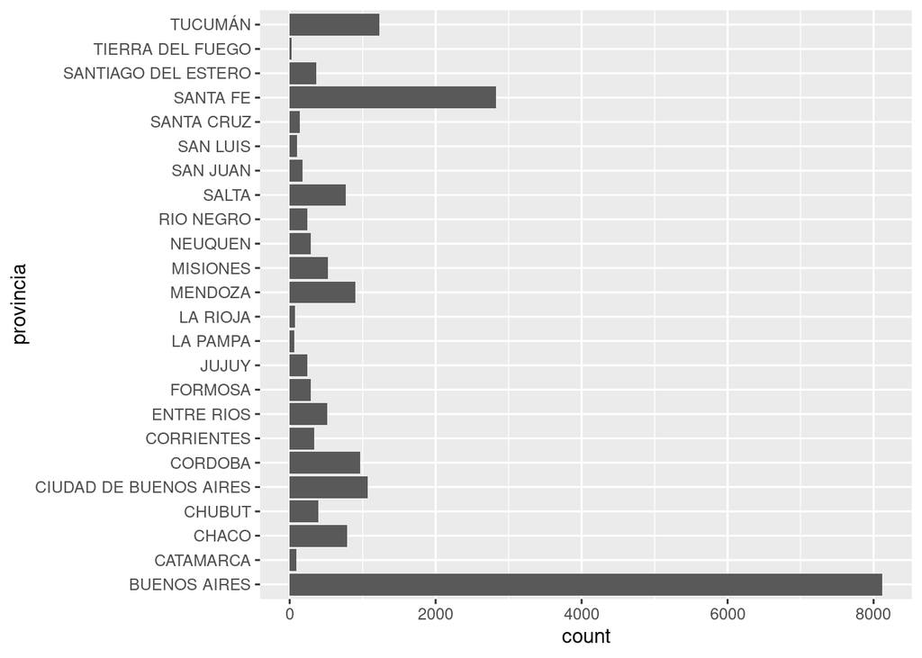

```r
> ggplot(df, aes(x=provincia))+
+         geom_bar()+
+         coord_flip()
```

Y con la rotación de texto.

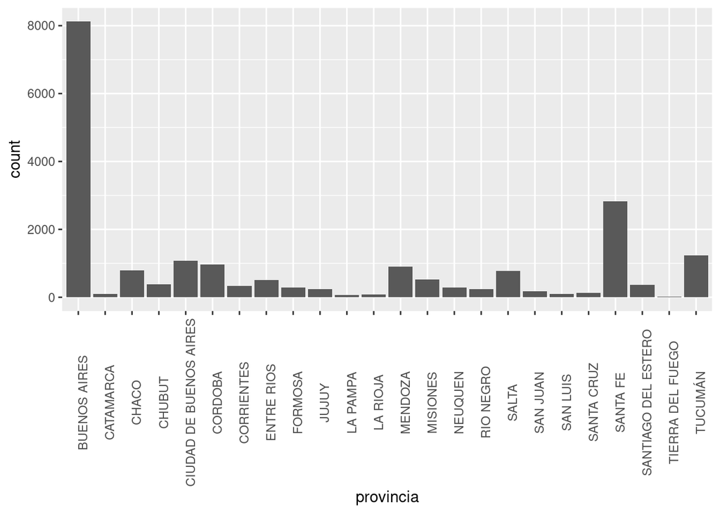

```r
> ggplot(df, aes(x=provincia))+
+         geom_bar()+
+         theme(axis.text.x = element_text(angle = 90))
```

Otros elementos que podemos modificar son los labels del gráfico. Con el atributo `labs` podemos modificar el título, subtítulo, epígrafe y ejes del gráfico.

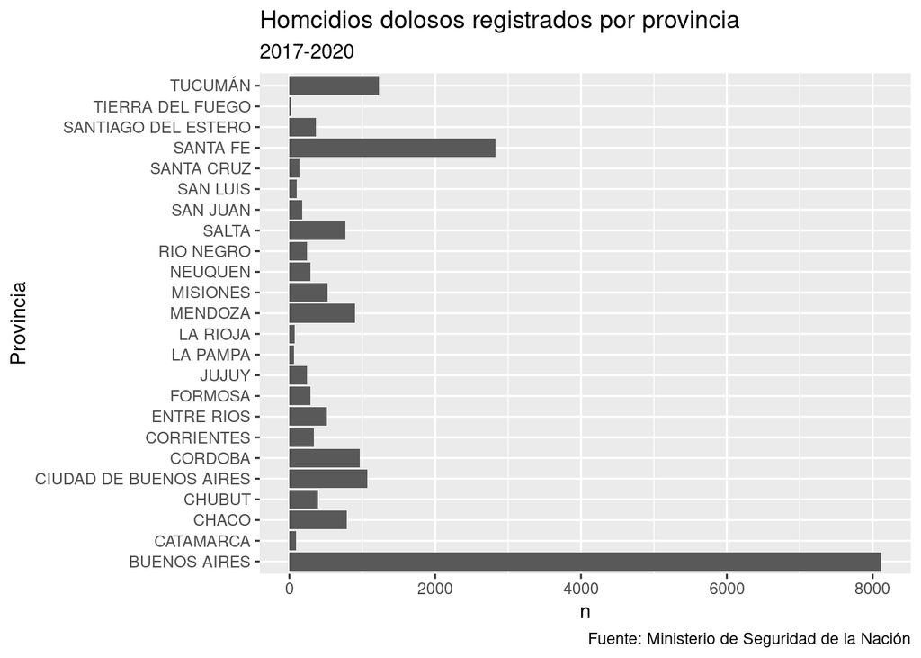

```r
> ggplot(df, aes(x=provincia))+
+         geom_bar()+
+         coord_flip()+
+         labs(
+         title = "Homcidios dolosos registrados por provincia",
+         subtitle = "2017-2020",
+         caption = "Fuente: Ministerio de Seguridad de la Nación",
+         x = "Provincia",
+         y = "n"
+         )
```